# W3cubDocs

/Ember.js

# Troubleshooting

Below are some common issues you may encounter when using the Inspector, along with the necessary steps to solve them. If your issue is not listed below, please submit an issue to the Inspector's [GitHub repo](https://github.com/emberjs/ember-inspector).

## Ember Application Not Detected

If the Inspector cannot detect an Ember application, you will see the following message:

[figure not shown]

## Using the Inspector with JS Bin

Due to the way JS Bin uses iframes, the Inspector doesn't work with edit mode. To use the Inspector with JS Bin, switch to the "live preview" mode by clicking on the arrow circled below.

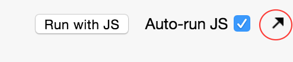

## Application is not Detected Without Reload

If you always have to reload your application after you open the Inspector, that may mean the application's booted state is corrupt. This happens if you call `advanceReadiness` or `deferReadiness` after the application has already booted.

## Data Adapter Not Detected

[figure not shown]

## Promises Not Detected

You click on the Promises tab, and see this message:

[figure not shown]

This happens if you are using a version of Ember < 1.3.

### Missing Promises

If the Promises tab is working, but there are Promises you can't find, it's probably because these Promises were created before the Inspector was activated. To detect Promises the moment the app boots, click on the `Reload` button below:

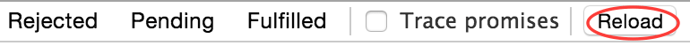

### Inspector Version Old on Firefox

Firefox addons need to go through a review process with each update, so the Inspector is usually one version behind.

Unfortunately we don't have control over the Firefox review process, so if you need the latest Inspector version, download and install it manually from [GitHub](https://github.com/emberjs/ember-inspector).

© 2017 Yehuda Katz, Tom Dale and Ember.js contributors  
Licensed under the MIT License.  
https://guides.emberjs.com/v2.15.0/ember-inspector/troubleshooting